# Relatório

Vitória

2023-06-12

# Resumo do Projeto Inicial

Sequenciamos, com pool-seq, populações de D. melanogaster ao longo da costa leste dos EUA em 1997 e em 2009/2010. Vamos comparar os padrões clinais nos dois períodos.

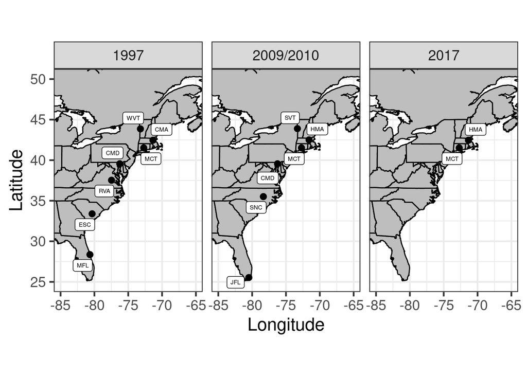

## SNP Calling

Depois de montar e mapear as sequencias (etapas que estão descritas aqui), chamamos os SNPs com o programa PoolSNP, que foi feito para chamar SNPs sequenciados por pool-seq. Ele aceita varias populações como input e devolve as frequências alélicas de cada população. É um programa bastante prático, porque possibilita que limites mínimos de profundidade e qualidade sejam estabelecidos. Esses limites valem para todas as populações, assim, temos a garantia que estamos comparando regiões que podem ser comparadas.Por exemplo, ele não consideraria SNPs que nas populações de 2009/2010 estão com boa qualidade, mas que em 1997 estão com a profundidade de leitura muito baixa. Outros parâmetros incluem o mínimo de reads que o alelo alternativo deve ter para ser considerado polimórfico e a frequência mínima que o SNP deve ter (esses dois parâmetros são calculados com base em todas as populações). Além do vcf com todos os SNPs identificados, PoolSNP também retorna um output com todas as posições que não foram chamadas porque não passaram no controle de qualidade.

Rodamos o PoolSNP com os seguintes parâmetros:

```bash
bash /home/vitoria/PoolSNP/PoolSNP.sh\
    mpileup={input.mpileup}\
    reference={input.ref}\
    names=CMD97B,WVT97,MFL97,RVA97,SVT09,CMD10,SNC10,JFL10,CMA97,HMA09,HMA17,MCT09,MCT17,MCT97\
    max-cov=0.98\
    min-cov=15\
    min-count=5\
    min-freq=0.001\
    miss-frac=0.1\
    jobs=24\
    BS=1\
    base-quality=20\
    allsites=0\
    output={params.outdir}
```

Retiramos a população ESC97 por causa da baixa qualidade do sequenciamento.

O vcf criado ficou assim:

```
## #CHROM   POS ID  REF ALT QUAL    FILTER  INFO    FORMAT  CMD97B  WVT97   MFL97   RVA97   SVT09   CMD10   SNC10   JFL10   CMA97   HMA09   HMA17   MCT09   MCT17   MCT97
## 2L   5224    .   A   T   .   .   ADP=43.07142857142857;NC=0  GT:RD:AD:DP:FREQ    0/0:39:0:39:0.0 0/1:39:1:40:0.03    0/0:38:0:38:0.0 0/1:45:1:46:0.02    0/1:42:1:43:0.02    0/0:36:0:36:0.0 0/0:29:0:29:0.0 0/0:40:0:40:0.0 0/1:52:1:53:0.02    0/0:49:0:49:0.0 0/0:43:0:43:0.0 0/1:49:1:50:0.02    0/0:…
## 2L   5273    .   T   A   .   .   ADP=43.785714285714285;NC=0 GT:RD:AD:DP:FREQ    0/0:29:0:29:0.0 0/0:41:0:41:0.0 0/0:44:0:44:0.0 0/0:46:0:46:0.0 0/0:46:0:46:0.0 0/0:39:0:39:0.0 0/0:35:0:35:0.0 0/0:43:0:43:0.0 0/0:52:0:52:0.0 0/1:44:1:45:0.02    0/1:46:2:48:0.04    0/0:49:0:49:0.0 0/1:33:1:34:0.03…
## 2L   5372    .   T   A   .   .   ADP=43.0;NC=0   GT:RD:AD:DP:FREQ    0/1:7:14:21:0.67    0/1:21:22:43:0.51   0/1:21:15:36:0.42   0/1:25:17:42:0.4    0/1:31:9:40:0.23    0/1:25:7:32:0.22    0/1:19:17:36:0.47   0/1:19:19:38:0.5    0/1:29:23:52:0.44   0/1:41:17:58:0.29   0/1:42:12:54:0.22   0/1:26:2…
## 2L   5495    .   A   T   .   .   ADP=38.92857142857143;NC=0  GT:RD:AD:DP:FREQ    0/0:16:0:16:0.0 0/0:38:0:38:0.0 0/0:24:0:24:0.0 0/0:32:0:32:0.0 0/1:35:1:36:0.03    0/0:30:0:30:0.0 0/0:31:0:31:0.0 0/0:36:0:36:0.0 0/1:45:1:46:0.02    0/1:63:1:64:0.02    0/0:49:0:49:0.0 0/1:49:1:50:0.02    0/0:38:0…
## 2L   5762    .   T   C   .   .   ADP=36.0;NC=0   GT:RD:AD:DP:FREQ    0/1:10:13:23:0.57   0/1:9:17:26:0.65    0/1:22:23:45:0.51   0/1:13:22:35:0.63   0/1:23:20:43:0.47   0/1:22:11:33:0.33   0/1:16:11:27:0.41   0/1:18:27:45:0.6    0/1:15:17:32:0.53   0/1:30:18:48:0.38   0/1:24:18:42:0.43   0/1:10:2…
## 2L   5776    .   C   G   .   .   ADP=36.0;NC=0   GT:RD:AD:DP:FREQ    0/1:24:3:27:0.11    0/0:25:0:25:0.0 0/0:41:0:41:0.0 0/1:32:1:33:0.03    0/1:40:4:44:0.09    0/1:31:1:32:0.03    0/0:26:0:26:0.0 0/1:45:1:46:0.02    0/0:37:0:37:0.0 0/1:46:3:49:0.06    0/0:43:0:43:0.0 0/0:39:0:39:0.0 0/1:39:1:40:…
## 2L   5803    .   A   G   .   .   ADP=33.92857142857143;NC=0  GT:RD:AD:DP:FREQ    0/0:19:0:19:0.0 0/1:18:2:20:0.1 0/0:31:0:31:0.0 0/0:34:0:34:0.0 0/1:47:3:50:0.06    0/1:28:1:29:0.03    0/0:23:0:23:0.0 0/1:45:1:46:0.02    0/0:36:0:36:0.0 0/1:53:1:54:0.02    0/1:37:1:38:0.03    0/1:37:1:38:0.03    …
## 2L   5813    .   G   T   .   .   ADP=33.57142857142857;NC=0  GT:RD:AD:DP:FREQ    ./.:.:.:.:. 0/0:17:0:17:0.0 0/0:29:0:29:0.0 0/1:33:2:35:0.06    0/1:47:2:49:0.04    0/0:29:0:29:0.0 0/0:23:0:23:0.0 0/0:46:0:46:0.0 0/1:38:1:39:0.03    0/0:50:0:50:0.0 0/0:42:0:42:0.0 0/0:41:0:41:0.0 0/1:35:1:36:0.03…
## 2L   5867    .   A   G   .   .   ADP=41.785714285714285;NC=0 GT:RD:AD:DP:FREQ    0/1:11:6:17:0.35    0/1:14:9:23:0.39    0/1:19:6:25:0.24    0/1:35:6:41:0.15    0/1:44:13:57:0.23   0/1:25:16:41:0.39   0/1:23:8:31:0.26    0/1:39:15:54:0.28   ./.:.:.:.:. 0/1:54:15:69:0.22   0/1:39:8:47:0.17    0/1:…
```

Filtramos o VCF de forma a incluir apenas os SNPs presentes nos cromossomso 2L, 2R, 3L, 3R e X. Também excluimos os SNPs que estavam a 5bp de indels e removemos regiões repetitivas usando os arquivos do repeatmasker.org.

## Identificação dos SNPs Clinais

Para identificar os SNPs clinais era preciso testar a clinalidade de cada SNP em cada período. Para isso, optamos por um GLM com função de ligação binomial das frequências alélicas contra latitude pesado para a cobertura e número de cromossomos nas amostras (mesmo modelo escolhido no trabalho do Murillo).

### Número efetivo de Cromossomos

O número efetivo de cromossomos (usado para pesar os GLMs) foi calculado da sequinte forma:

```r
freqs[, NE := ((1/depth) + (1/n_chrom))^-1]
```

Onde `depth` é a profundidade de leitura daquele site naquela população e `n_chrom` é o número de cromossomos (nº de moscas x2) no pool. O número de cromossomos amostrados em cada população estava na tabela de metadados e a profundidade de leitura foi extraída do vcf, os detalhes estão no script n_chrom.

| population | latitude | n_chrom | CHROM | POS | REF | ALT | depth | freq | NE |
| --- | --- | --- | --- | --- | --- | --- | --- | --- | --- |
| CMA97 | 42.46 | 280 | 2L | 5762 | T | C | 32 | 0.53 | 28.71795 |
| CMA97 | 42.46 | 280 | 2L | 5776 | C | G | 37 | 0.00 | 32.68139 |
| CMA97 | 42.46 | 280 | 2L | 5803 | A | G | 36 | 0.00 | 31.89873 |
| CMA97 | 42.46 | 280 | 2L | 5813 | G | T | 39 | 0.03 | 34.23197 |
| CMA97 | 42.46 | 280 | 2L | 6256 | G | A | 19 | 0.16 | 17.79264 |
| CMA97 | 42.46 | 280 | 2L | 6353 | C | T | 25 | 0.68 | 22.95082 |
| CMA97 | 42.46 | 280 | 2L | 6400 | A | G | 28 | 0.04 | 25.45455 |
| CMA97 | 42.46 | 280 | 2L | 6607 | C | T | 35 | 0.03 | 31.11111 |
| CMA97 | 42.46 | 280 | 2L | 6631 | A | G | 39 | 0.05 | 34.23197 |
| CMA97 | 42.46 | 280 | 2L | 6690 | C | G | 42 | 0.07 | 36.52174 |

### GLM

Antes de correr o GLM, as populações de 1997 e 2009/2010 foram separadas em dois arquivos diferentes. Todos os SNPs cuja frequência era zero em todas as população de uma dada época foram removidos. Os GLMs foram calculados com o script glm_script.R. Basicamente, isso foi feito da seguinte forma:

```r
nested_snps[, models := purrr::map(data, ~ glm(freq~latitude,
                                               weights = NE,
                                               data = .x,
                                               family = binomial()))]
```

```
##     position2              data    models
##  1:   2L:5762 <data.table[6x8]> <glm[30]>
##  2:   2L:5776 <data.table[6x8]> <glm[30]>
##  3:   2L:5803 <data.table[6x8]> <glm[30]>
##  4:   2L:5813 <data.table[5x8]> <glm[30]>
##  5:   2L:6256 <data.table[6x8]> <glm[30]>
##  6:   2L:6353 <data.table[5x8]> <glm[30]>
##  7:   2L:6400 <data.table[6x8]> <glm[30]>
##  8:   2L:6607 <data.table[5x8]> <glm[30]>
##  9:   2L:6631 <data.table[5x8]> <glm[30]>
## 10:   2L:6690 <data.table[5x8]> <glm[30]>
```

olhando para um modelo:

```
##
## Call:  glm(formula = freq ~ latitude, family = binomial(), data = .x,
##     weights = NE)
##
## Coefficients:
## (Intercept)     latitude
##    0.176017    -0.002555
##
## Degrees of Freedom: 5 Total (i.e. Null);  4 Residual
## Null Deviance:       14.63
## Residual Deviance: 14.63     AIC: 38.8
```

```
##
## Call:
## glm(formula = freq ~ latitude, family = binomial(), data = .x,
##     weights = NE)
##
## Deviance Residuals:
##       1        2        3        4        5        6
##  0.1408   0.4518  -3.3306  -0.1938   1.2366   1.3200
##
## Coefficients:
##              Estimate Std. Error z value Pr(>|z|)
## (Intercept)  0.176017   1.070062   0.164    0.869
## latitude    -0.002555   0.027856  -0.092    0.927
##
## (Dispersion parameter for binomial family taken to be 1)
##
##     Null deviance: 14.634  on 5  degrees of freedom
## Residual deviance: 14.626  on 4  degrees of freedom
## AIC: 38.801
##
## Number of Fisher Scoring iterations: 4
```

Então extrai o coeficiente de inclinação e o p-valor associado ao coeficiente de inclinação de cada glm:

```
##     position2              data    models           summary coefficients
##  1:   2L:5762 <data.table[6x8]> <glm[30]> <summary.glm[17]> -0.002554832
##  2:   2L:5776 <data.table[6x8]> <glm[30]> <summary.glm[17]>  0.027677329
##  3:   2L:5803 <data.table[6x8]> <glm[30]> <summary.glm[17]> 16.190050706
##  4:   2L:5813 <data.table[5x8]> <glm[30]> <summary.glm[17]>  0.056249712
##  5:   2L:6256 <data.table[6x8]> <glm[30]> <summary.glm[17]>  0.201030116
##  6:   2L:6353 <data.table[5x8]> <glm[30]> <summary.glm[17]> -0.032565685
##  7:   2L:6400 <data.table[6x8]> <glm[30]> <summary.glm[17]>  0.367880703
##  8:   2L:6607 <data.table[5x8]> <glm[30]> <summary.glm[17]>  0.022473458
##  9:   2L:6631 <data.table[5x8]> <glm[30]> <summary.glm[17]> -0.076816160
## 10:   2L:6690 <data.table[5x8]> <glm[30]> <summary.glm[17]> -0.052349504
##        p_value
##  1: 0.92692285
##  2: 0.79901715
##  3: 0.99932800
##  4: 0.61457485
##  5: 0.28448751
##  6: 0.38373134
##  7: 0.53633894
##  8: 0.82123467
##  9: 0.09788652
## 10: 0.26572841
```

### p-valores

A distribuição dos p-valores ficou assim:

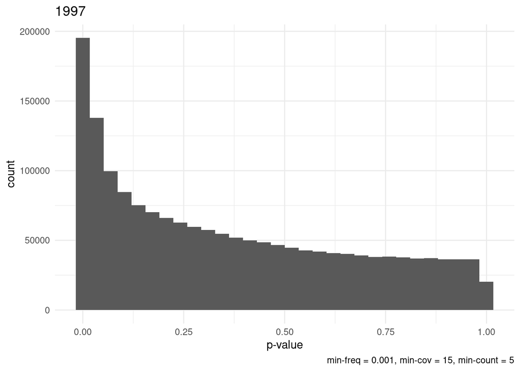

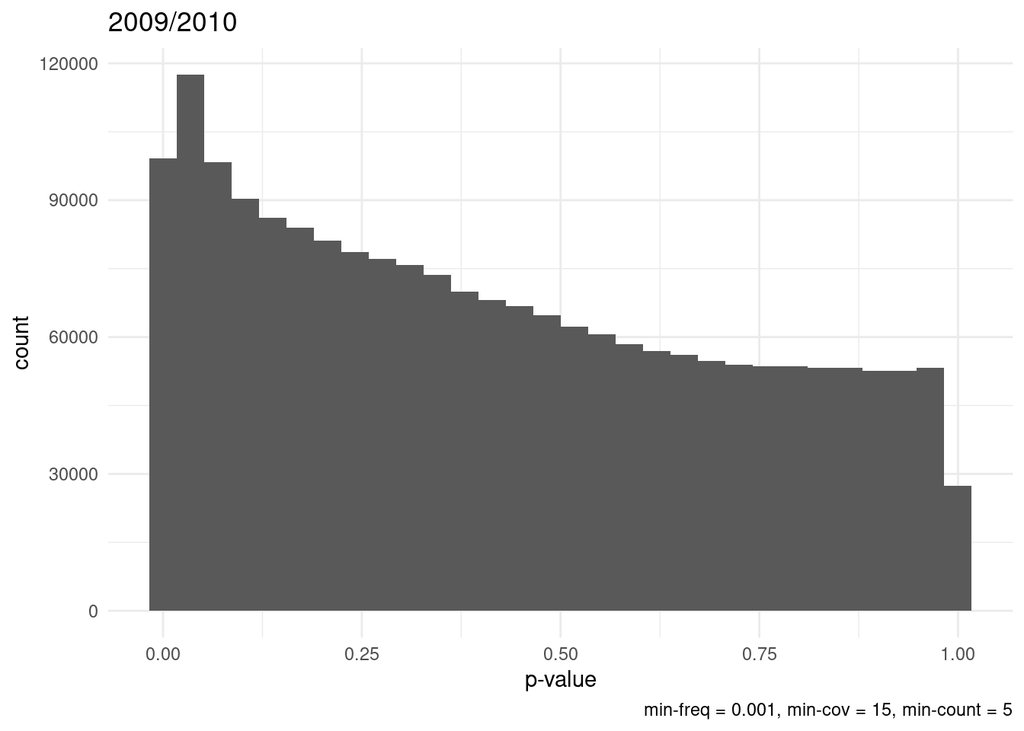

# Resultados exploratórios

## PCA

Fiz um PCA com os SNPs identificados:

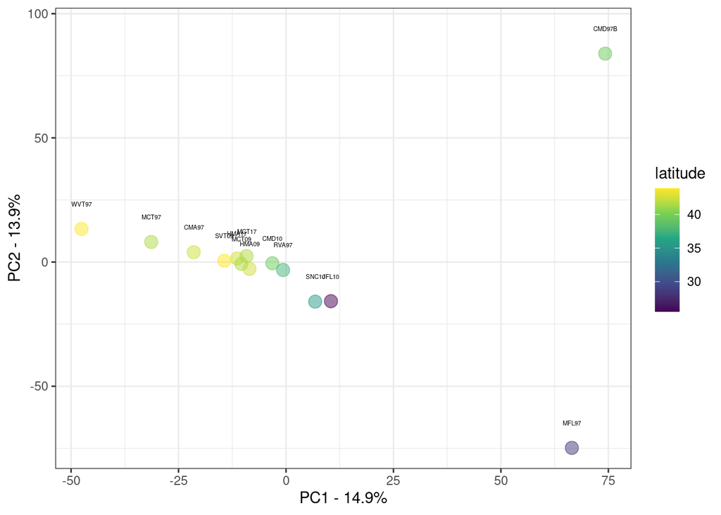

Com PCAs separados por época:

#### 1997

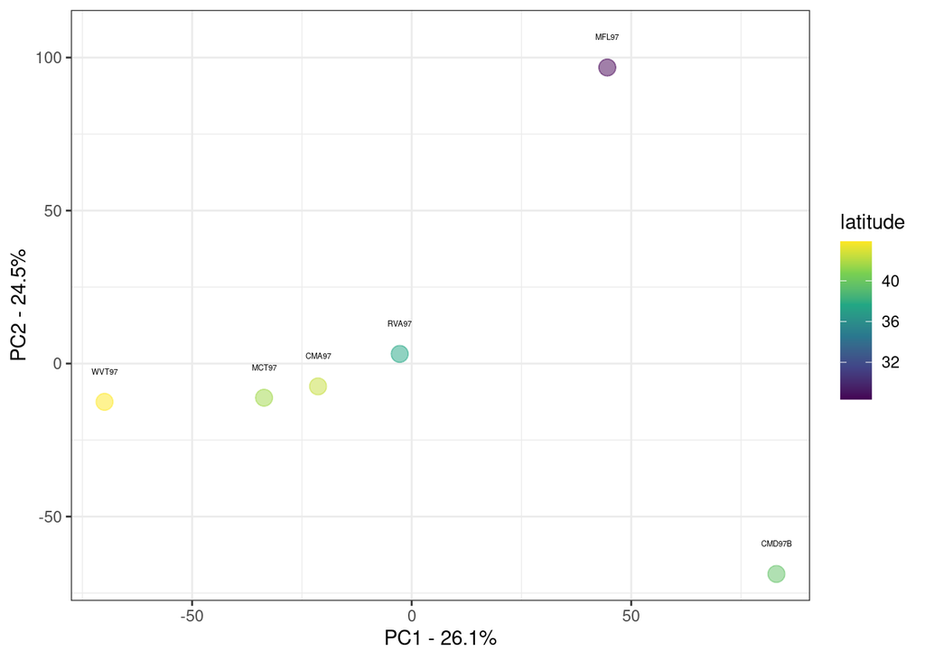

#### 2009/2010

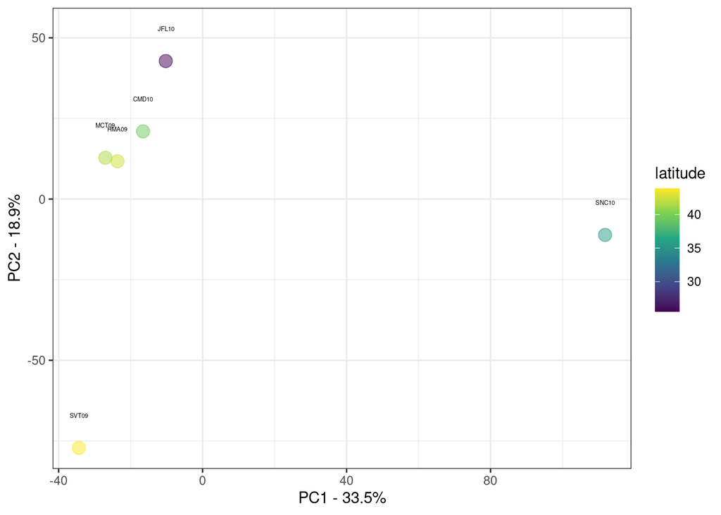

## Manhattan Plots

Eu queria ver como esses p-valores estão distribuídos no genoma. Então fiz Manhattan plots para 1997 e 2009/2010.

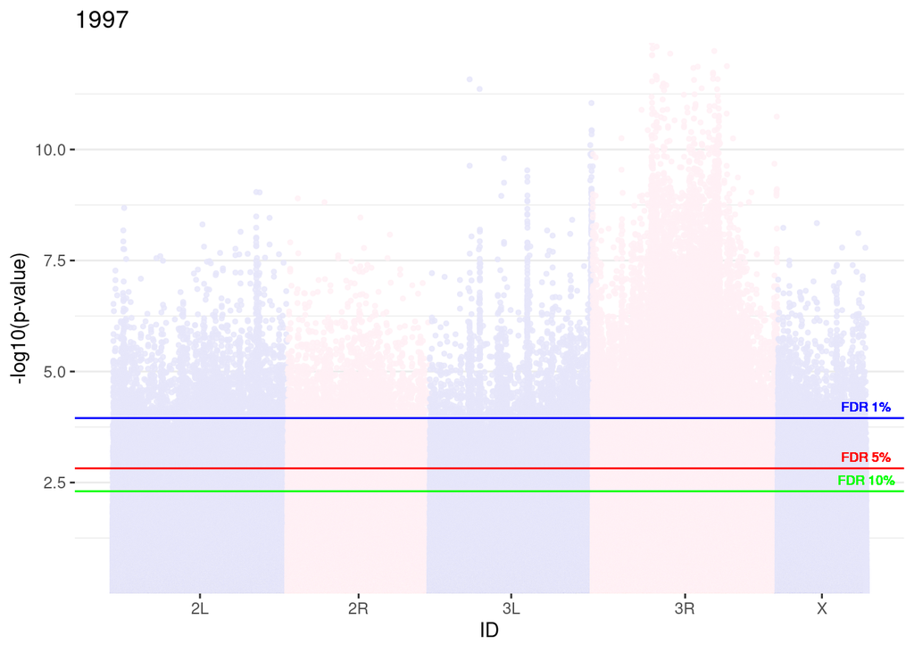

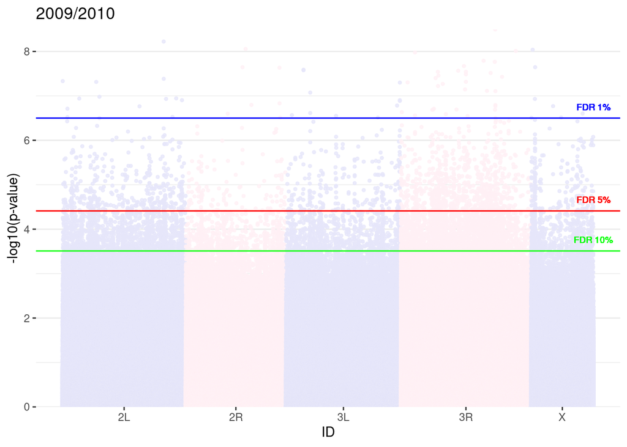

## Inversões

Pelo gráfico anterior deu para perceber que a região do 3R tem mais SNPs clinais que as demais. Então usei o pipeline descrito em Kapun et al. 2014 (usando inclusive os mesmos scripts) para calcular as frequências das inversões.

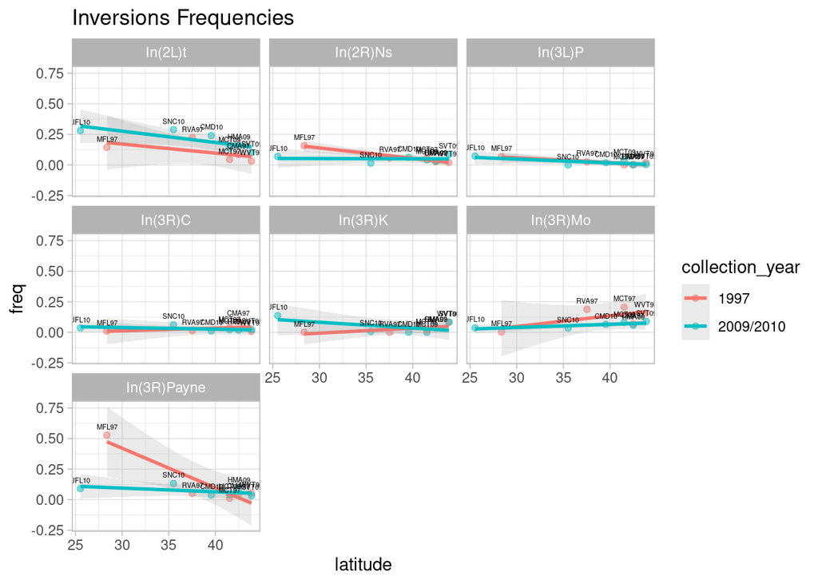

## PCA with African and European samples

Peguei duas populações do DGN (Drosophila Genome Nexus), uma Africana (da Zâmbia) e outra Europeia (da França). Refiz o PCA com essas amostras.

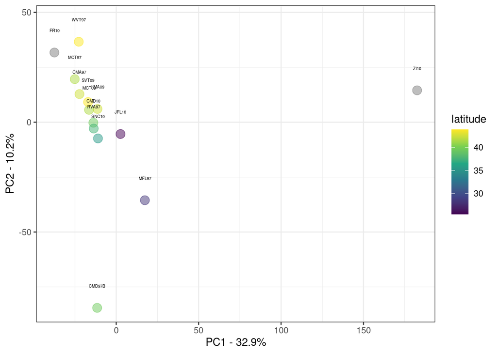

## Enrichment analysis

Para entender se havia algum enriquecida para SNPs clinais, anotamos todos os SNPs identificados com snpEff. Isso foi feito com o seguinte comando:

```bash
java -Xmx8g -jar /home/vitoria/bin/snpEff/snpEff.jar BDGP6.32.105 {input} > {output}
```

O snpEff anota varios efeitos por SNP e os ordena por impacto, com o efeito de maior impacto primeiro. Como não daria par aanalizar todos os efeitos, fiquei apenas com o efeito de maior impacto de cada SNP. Isso foi feito nesse script. Os SNPs clinais estavam distribuidos assim:

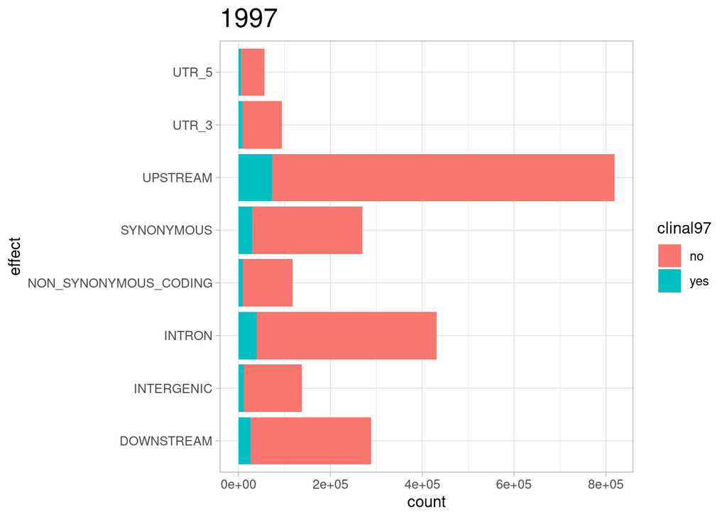

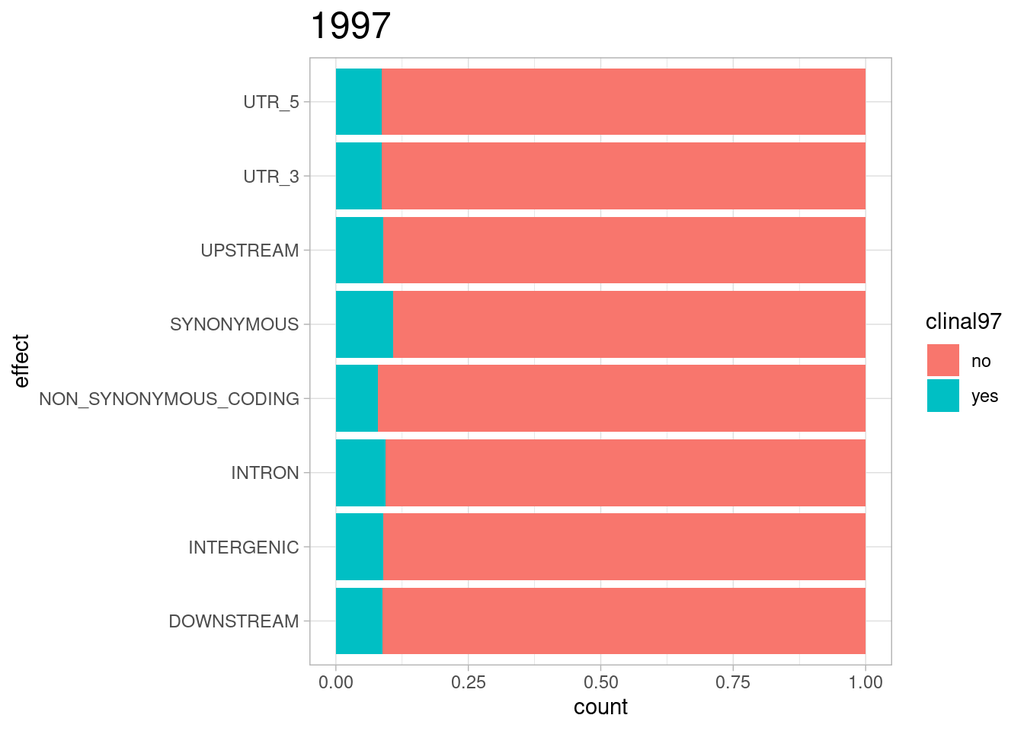

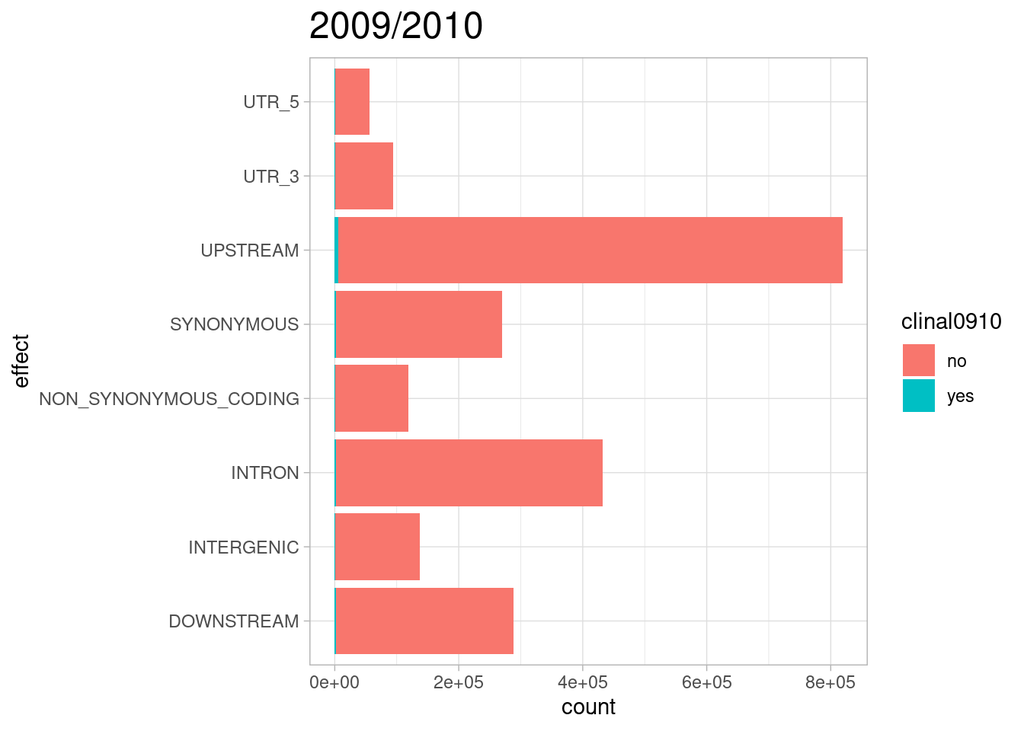

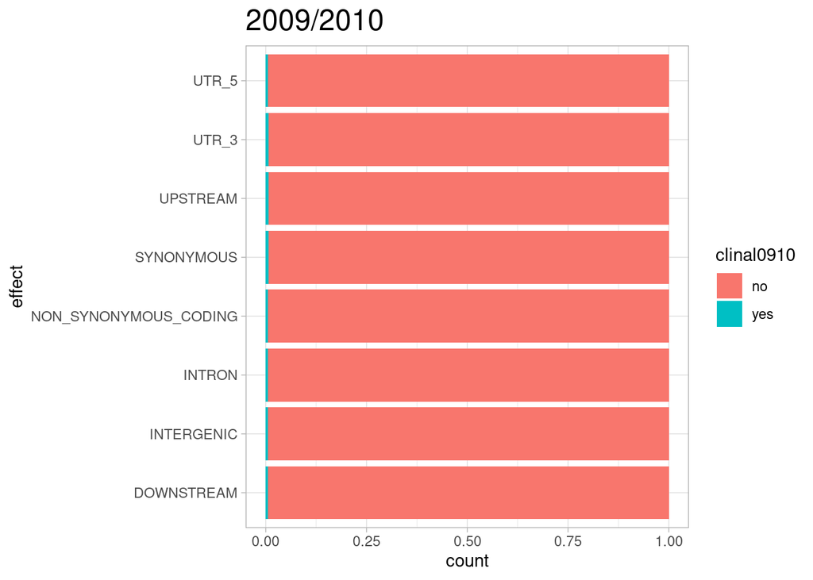

Em seguida, montei a sequinte tabela:

| CHROM | POS | clinal97 | clinal0910 | REF | ALT | ANN | region | DOWNSTREAM | INTERGENIC | INTRON | NON_SYNONYMOUS_CODING | SYNONYMOUS | UPSTREAM | UTR_3 | UTR_5 |
| --- | --- | --- | --- | --- | --- | --- | --- | --- | --- | --- | --- | --- | --- | --- | --- |
| 2L | 5762 | no | no | T | C | upstream_gene_variant | UPSTREAM | 0 | 0 | 0 | 0 | 0 | 1 | 0 | 0 |
| 2L | 5776 | no | no | C | G | upstream_gene_variant | UPSTREAM | 0 | 0 | 0 | 0 | 0 | 1 | 0 | 0 |
| 2L | 5803 | no | no | A | G | upstream_gene_variant | UPSTREAM | 0 | 0 | 0 | 0 | 0 | 1 | 0 | 0 |
| 2L | 5813 | no | no | G | T | upstream_gene_variant | UPSTREAM | 0 | 0 | 0 | 0 | 0 | 1 | 0 | 0 |
| 2L | 6256 | no | no | G | A | upstream_gene_variant | UPSTREAM | 0 | 0 | 0 | 0 | 0 | 1 | 0 | 0 |
| 2L | 6353 | no | no | C | T | upstream_gene_variant | UPSTREAM | 0 | 0 | 0 | 0 | 0 | 1 | 0 | 0 |
| 2L | 6400 | no | no | A | G | upstream_gene_variant | UPSTREAM | 0 | 0 | 0 | 0 | 0 | 1 | 0 | 0 |
| 2L | 6607 | no | no | C | T | upstream_gene_variant | UPSTREAM | 0 | 0 | 0 | 0 | 0 | 1 | 0 | 0 |
| 2L | 6631 | no | no | A | G | upstream_gene_variant | UPSTREAM | 0 | 0 | 0 | 0 | 0 | 1 | 0 | 0 |
| 2L | 6690 | no | no | C | G | upstream_gene_variant | UPSTREAM | 0 | 0 | 0 | 0 | 0 | 1 | 0 | 0 |

Antes de continuar com as análises de enriquecimento, eu exclui alguns SNPs com algumas anotações, dentre elas: start_gained, stop_gained, synonymous_stop, start_lost, stop_lost, non_synonymous_start, splice e non_coding_transcript.

Para obter o odds ratio para cada efeito rodei uma regressão logistica do status clinal (nesse caso, usei FDR 0.1) em relação ao efeito

```r
models <- foreach(i = 1:n_effects) %dopar% {
  glm(data = dcasted_tiny_clinal_status,
      paste(clinal_year," ~ ", EFFECTS[[i]]),
      family = binomial)
}
```

A ideia era comparar a chance do SNP ser clinal dentre os SNPs de um determinado efeito com a chance do SNP ser clinal dentre todas os outros efeitos:

$$log(\frac{UPSTREAM \& Clinal}{UPSTREAM \& Not Clinal}) -
log(\frac{Not UPSTREAM \& Clinal}{Not UPSTREAM \& Not Clinal})$$

Um exemplo com apenas SNPs no cromossomo 2L de um desses modelos:

```
##
## Call:
## glm(formula = clinal0910 ~ UPSTREAM, family = binomial, data = dcasted_tiny_clinal_status)
##
## Deviance Residuals:
##     Min       1Q   Median       3Q      Max
## -0.1180  -0.1180  -0.1180  -0.1154   3.1670
##
## Coefficients:
##             Estimate Std. Error z value Pr(>|z|)
## (Intercept) -4.96383    0.02148 -231.04   <2e-16 ***
## UPSTREAM1   -0.04438    0.03494   -1.27    0.204
## ---
## Signif. codes:  0 '***' 0.001 '**' 0.01 '*' 0.05 '.' 0.1 ' ' 1
##
## (Dispersion parameter for binomial family taken to be 1)
##
##     Null deviance: 41974  on 514115  degrees of freedom
## Residual deviance: 41972  on 514114  degrees of freedom
## AIC: 41976
##
## Number of Fisher Scoring iterations: 7
```

Em seguida usei bootstrap para obter os intervalos de confiança:

```r
intervals_percentile <- foreach(i = 1:n_effects) %dopar% {
  reg_intervals(paste(clinal_year," ~ ", EFFECTS[[i]]),
                data = dcasted_tiny_clinal_status,
                model_fn = "glm",
                family = binomial,
                keep_reps = TRUE,
                type = "percentile")
}
```

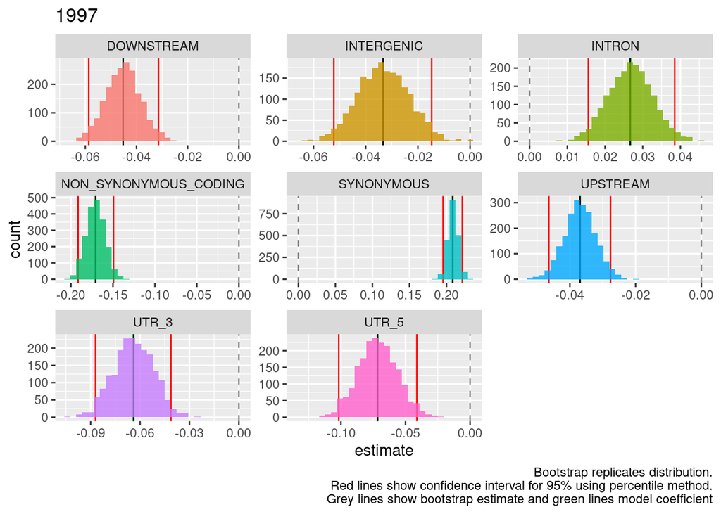

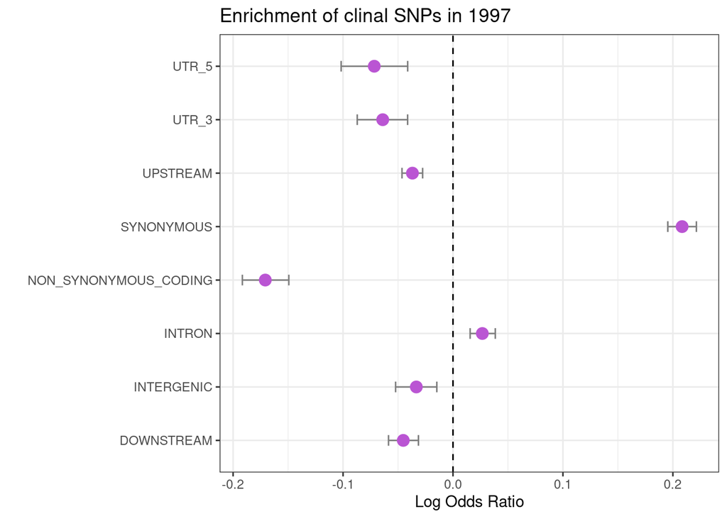

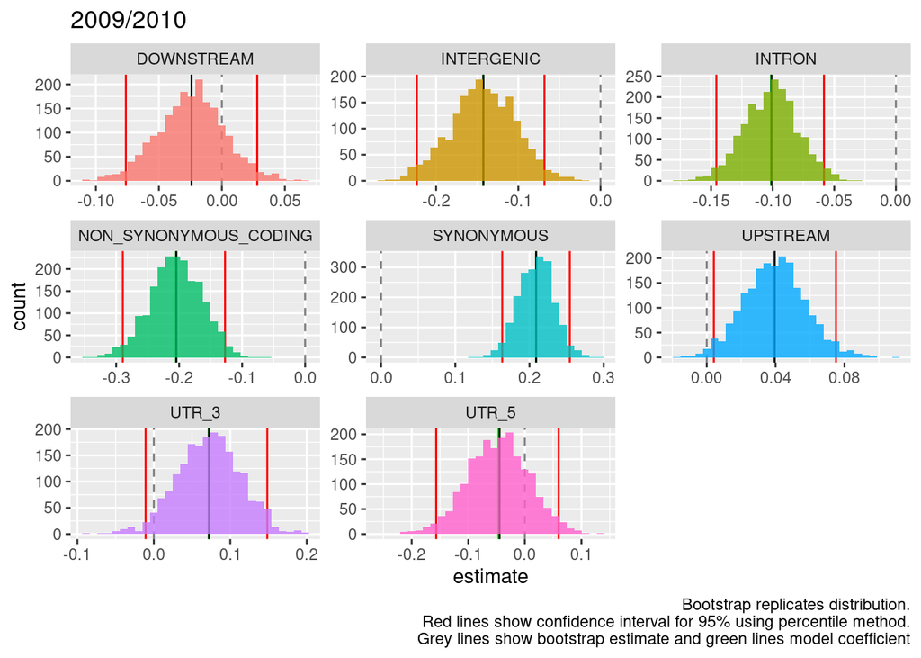

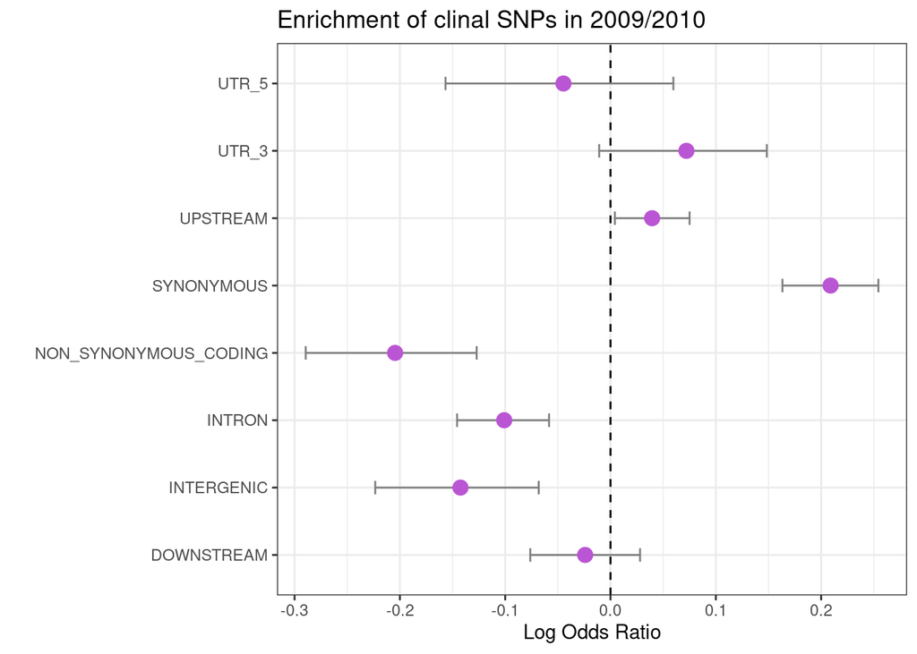